# Homework 2 - BIOST 544

John Schoof

11/3/2020

### Question 1

```r
set.seed(1)
simulate.perm.test <- function(dat){

    perm.one.trial <- function(dat){
      ## create the permuted data
      perm <- sample(0:1, nrow(dat), replace=TRUE)
      perm.data <- dat
      perm.data$tx <- perm

      ## calculate the difference in proportion responding positively
      prop.treat <- perm.data %>%
                        filter(tx == 1) %>%
                        summarise(prop = mean(outcome)) %>%
                        .$prop
      prop.control <- perm.data %>%
                        filter(tx == 0) %>%
                        summarise(prop = mean(outcome)) %>%
                        .$prop

      prop.diff <- prop.treat - prop.control

      return(prop.diff)
    }

  # Simulate perm.one.trial 10,000 times to create sampling distribution
  nsim <- 1e4
  permuted.stats <- data.frame(replicate(nsim, perm.one.trial(dat)))
  colnames(permuted.stats) <- c("prop.diff")

  # Calculate observed difference in proportions
  resp.prop.treat <- dat %>%
                      filter(tx == 1) %>%
                      summarise(prop = mean(outcome)) %>%
                      .$prop
  resp.prop.control <- dat %>%
                        filter(tx == 0) %>%
                        summarise(prop = mean(outcome)) %>%
                        .$prop
  resp.prop.diff <- resp.prop.treat - resp.prop.control

  # calculate a p value that null is consistent with observed difference
  pval <- 1-mean(permuted.stats$prop.diff <= resp.prop.diff)

  # Histogram of sampling distribution
  hist <- ggplot(data = permuted.stats, mapping = aes(x=prop.diff)) +
            geom_histogram(binwidth=0.08) +
            geom_vline(aes(xintercept = resp.prop.diff), color = "red") +
            labs(x = "Difference in Outcome between Treatment and Control",
                 y = "Count",
                 title = "Sampling Distribution of Treatment Effect")

  # return p value and histogram
  return(list(pval, hist))

}
```

### Question 2a

Similar to question 1, below is a function that does a re-randomization of treatment assignments to evaluate if the treatment effect that is observed in our dataset is consistent with the null hypothesis that the standard of care is at least as effective as the new-treatment. However, this function uses the adaptive randomization scheme as described by question 2.

The below function called “adaptive.random” takes in a dataset with three columns, one called “tx,” “outcome,” and “order,” and returns a p-value corresponding to the above hypothesis test and a histogram showing where the observed difference lies in the sampling distribution. As in question 1, there is an internal function that runs one trial of the permuted simulation that is called “adaptive.one.trial.” The main difference here is that within the “adaptive.one.trial” function a for loop is run in order to randomize patients one at a time. This for loop recalculates $p_{new}$ for each patient that is assigned based on the outcomes of the previous patients. As in question 1, the “adaptive.one.trial” function ends by calculating the difference in the proportion of patients that respond positively between treatment and control groups in this single permuted simulation. The “adaptive.random” function then replicates this 10,000 times and returns a p-value and a histogram just like in question 1.

```r
  adaptive.random <- function(dat){

    adaptive.one.trial <- function(dat){
    success.new <- 0
    failure.old <- 0
    perm.data <- dat
    # calculate p.new using defined randomization scheme
    for(i in 1:nrow(dat)){
    p.new <- (1 + 3*(success.new + failure.old))/(2+3*(i-1))

    perm.data$tx[i] <- rbinom(1, 1, p.new)

    if (perm.data$tx[i]==1 & perm.data$outcome[i]==1){
      success.new <- (success.new+1) }
    if (perm.data$tx[i]==0 & perm.data$outcome[i]==0) {
      failure.old=failure.old+1}

    }

    prop.treat <- perm.data %>%
                      filter(tx == 1) %>%
                      summarise(prop = mean(outcome)) %>%
                      .$prop
    prop.control <- perm.data %>%
                      filter(tx == 0) %>%
                      summarise(prop = mean(outcome)) %>%
                      .$prop

    prop.diff2 <- prop.treat - prop.control

    return(prop.diff2)
  }

  # Simulate perm.one.trial 10,000 times to create sampling distribution
    nsim <- 1e4
    set.seed(1)
    permuted.2b <- data.frame(replicate(nsim, adaptive.one.trial(dat)))
    colnames(permuted.2b) <- c("prop.diff2")

  # Calculate observed difference in proportions
    resp.prop.treat <- dat %>%
                        filter(tx == 1) %>%
                        summarise(prop = mean(outcome)) %>%
                        .$prop
    resp.prop.control <- dat %>%
                          filter(tx == 0) %>%
                          summarise(prop = mean(outcome)) %>%
                          .$prop
    resp.prop.diff <- resp.prop.treat - resp.prop.control

  # calculate a p value that null is consistent with observed difference
    pval2 <- 1-mean(permuted.2b$prop.diff2 <= resp.prop.diff)

  # Histogram
    plot2 <- ggplot(data = permuted.2b, mapping = aes(x=prop.diff2)) +
              geom_histogram(binwidth=0.08) +
              geom_vline(aes(xintercept = resp.prop.diff), color = "red") +
              labs(x = "Difference in Outcome between Treatment and Control",
                   y = "Count",
                   title = "Sampling Distribution of Treatment Effect for Adaptive Randomization")

  # Return p-value and histogram
    return(list(pval2, plot2))
  }
```

### Question 2b

Below, the “adapt.random” function from question 2a is run on the “HW2-adaptive-trial.txt” dataset. This tests the null hypothesis that the standard of care is at least as effective as the new treatment. Returned is a p-value of 0.205. This means that we do not have evidence to reject the null hypothesis at the $\alpha$ = 0.05 significance level. In other words, if the null hypothesis were true and the standard of care is in fact at least as effective as the new treatment, then seeing a our sample wouldn’t be that unusual.

```r
  set.seed(1)
  dat.q2 <- hw2
  adaptive.random(dat.q2)
```

```
## [[1]]
## [1] 0.205
##
## [[2]]
```

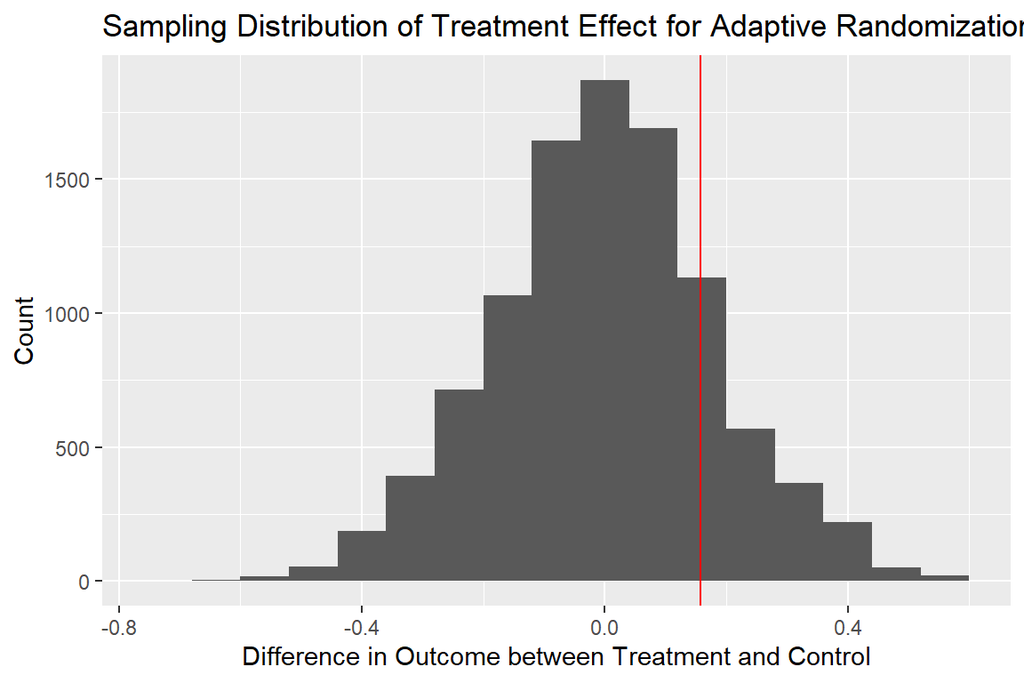

### Question 3

After running the function from question 1 on the “HW2-adaptive-trial.txt” dataset, a p-value of 0.154 is returned. This means that we do not have evidence to reject the null hypothesis at the $\alpha$ = 0.05 significance level. In other words, if the null hypothesis were true and the standard of care is in fact at least as effective as the new treatment, then seeing a our sample wouldn’t be that unusual.

```r
  dat.q1 <- hw2[ , 1:2]

  set.seed(1)
  simulate.perm.test(dat.q1)
```

```
## [[1]]
## [1] 0.154
##
## [[2]]
```

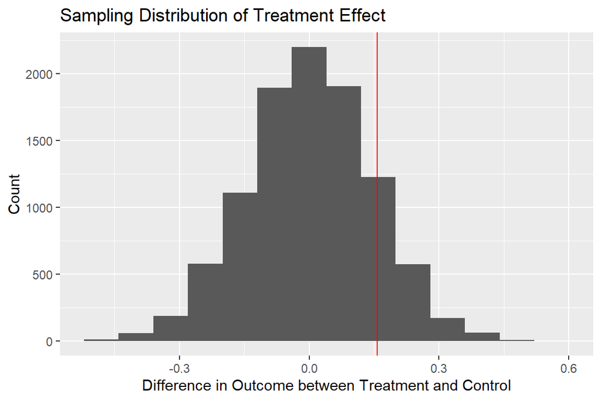